# 고급 시각화 - (ggplot2)를 중심으로

Sangkon Han(sangkon@pusan.ac.kr)

2023-03-21

# 패키지 설치 및 데이터 준비

`lattice` 패키지를 설치하고, 해당 패키지를 활성화하세요.

```r
install.packages("lattice", repos = "https://cran.us.r-project.org")
library(lattice)
```

`mlmRev` 패키지를 설치하고, 해당 패키지를 사용해서 데이터를 불러옵니다.

```r
install.packages("mlmRev", repos = "https://cran.us.r-project.org")
library(mlmRev)
```

해당 데이터를 불러옵니다.

```r
data("Chem97")
```

먼저 데이터의 구성을 확인합니다.

```r
str(Chem97)
```

```
## 'data.frame':    31022 obs. of  8 variables:
##  $ lea      : Factor w/ 131 levels "1","2","3","4",..: 1 1 1 1 1 1 1 1 1 1 ...
##  $ school   : Factor w/ 2410 levels "1","2","3","4",..: 1 1 1 1 1 1 1 1 1 1 ...
##  $ student  : Factor w/ 31022 levels "1","2","3","4",..: 1 2 3 4 5 6 7 8 9 10 ...
##  $ score    : num  4 10 10 10 8 10 6 8 4 10 ...
##  $ gender   : Factor w/ 2 levels "M","F": 2 2 2 2 2 2 2 2 2 2 ...
##  $ age      : num  3 -3 -4 -2 -1 4 1 4 3 0 ...
##  $ gcsescore: num  6.62 7.62 7.25 7.5 6.44 ...
##  $ gcsecnt  : num  0.339 1.339 0.964 1.214 0.158 ...
```

데이터의 앞부분 30개를 살펴보겠습니다.

```r
head(Chem97, 30)
```

```
##    lea school student score gender age gcsescore     gcsecnt
## 1    1      1       1     4      F   3     6.625  0.33931571
## 2    1      1       2    10      F  -3     7.625  1.33931571
## 3    1      1       3    10      F  -4     7.250  0.96431571
## 4    1      1       4    10      F  -2     7.500  1.21431571
## 5    1      1       5     8      F  -1     6.444  0.15831571
## 6    1      1       6    10      F   4     7.750  1.46431571
## 7    1      1       7     6      F   1     6.750  0.46431571
## 8    1      1       8     8      F   4     6.909  0.62331571
## 9    1      1       9     4      F   3     6.375  0.08931571
## 10   1      1      10    10      F   0     7.750  1.46431571
## 11   1      1      11    10      F  -1     7.857  1.57131571
## 12   1      1      12     8      F   1     7.333  1.04731571
## 13   1      1      13    10      F   1     7.750  1.46431571
## 14   1      2      14    10      M   0     7.700  1.41431571
```

[output cut: 16 more lines]

```r
Chem97
```

[output not shown]

## 간단한 그래프 작성

`lattice`는 간단한 직교형태의 그래픽을 구성하는 방법을 포함하고 있습니다. `R`에서 제공하는 것과 별도로 작동하며, 데이터 셋의 특징을 전반적으로 보여주는 것이 주요한 특징입니다.

### 히스토그래프

`histogram()` 함수를 이용하여 데이터 시각화를 시작해보겠습니다.

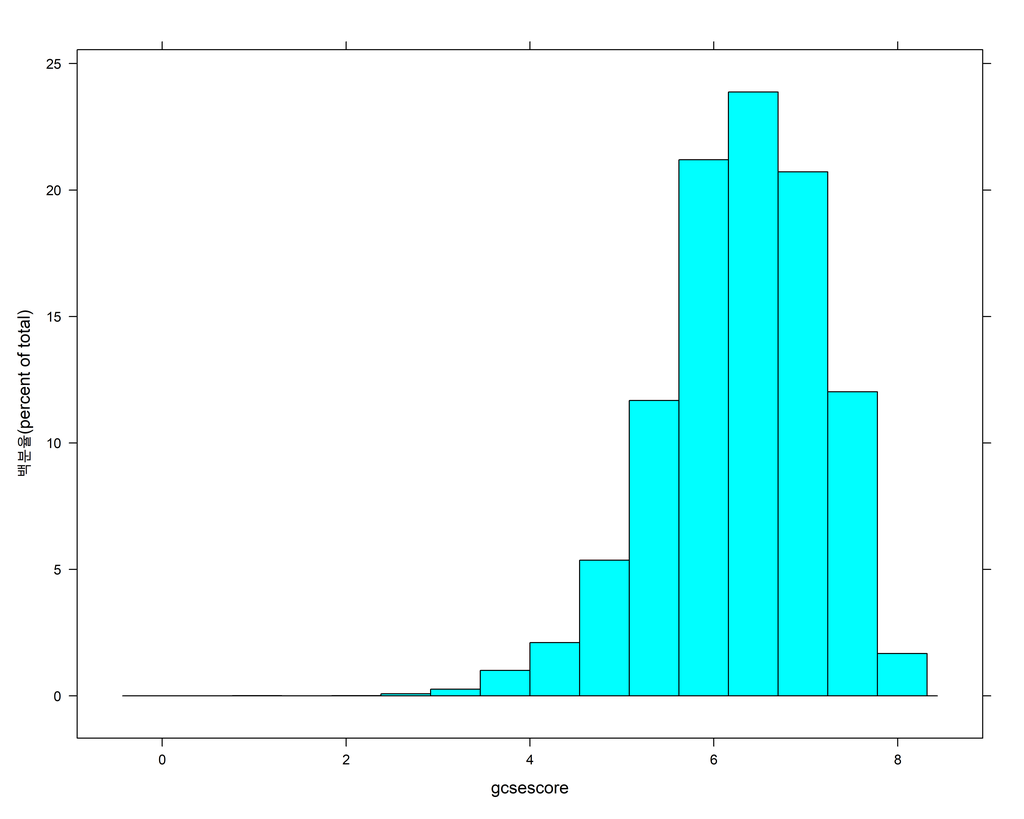

```r
histogram(~gcsescore, data = Chem97)
```

`score` 변수를 **조건**변수로 지정하여 데이터를 시각화하는 방법은 아래와 같습니다. score 변수를 사용하면 주황색 기준으로 격자형으로 분리해서 분포를 보여줍니다. 하지만 해당 주황색의 값을 정확하게 알기 쉽지 않습니다.

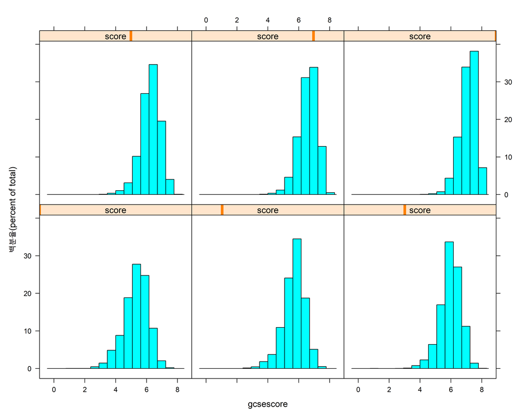

```r
histogram(~gcsescore | score, data = Chem97)
```

`factor`를 사용하여 `score` 값을 손쉽게 확인할 수 있습니다. factor는 범주 값을 반환하는 것으로(0~10) score를 x축에 대입하면, 순서대로 적용됩니다.

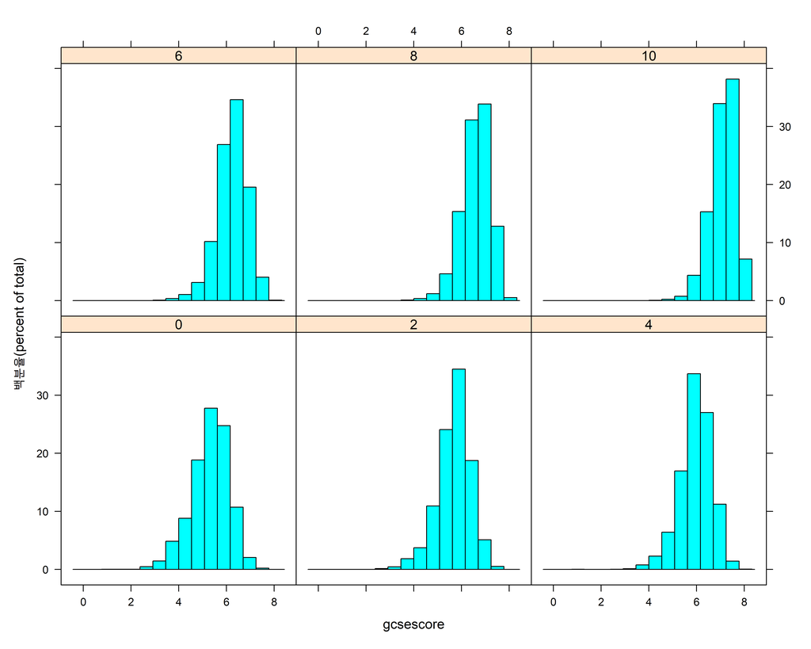

```r
histogram(~gcsescore | factor(score), data = Chem97)
```